# Lecture 4

Markdown exercises

Misja Mikkers and Gertjan Verhoeven

In this notebook we will exercise using Markdown to format our documents.

## What is markdown

In Markdown you can just create plain text, but you can also do some formatting. That’s what this lesson is about.

*Remember you can google everything*

A good [“cheat sheet can be found here”](https://raw.githubusercontent.com/rstudio/cheatsheets/master/rmarkdown-2.0.pdf)

## Formatting

For starters, it is possible to simply type text.

## Structure

But it is also possible to add structure to the text:

```
# Chapter
## Section
### Subsection
#### etc
##### etc
```

# Chapter

## Section

### Subsection

#### etc

##### etc

### Lists

Four spaces for sub-items

```
* unordered list
* item 2
    + sub-item 1
    + sub-item 2

1. ordered list
2. item 2
    a) sub-item 1
    b) sub-item 2
```

**Exercise**:

Now try to make a list of main points (1,2,3) and sub-points (3a, 3b) and knit to see the result.

1. main
2. also main
3. more main
   - sub 1
   - sub 2

### Text formatting

**Exercise**:

Make one **word** in this sentence bold.

### Tables

```
First name | Surname |
----------- | ------------ |
Gertjan | Verhoeven |
Misja | Mikkers |
```

**Exercise**:

1. Copy this table
2. Add a line with your own name
3. Add a column with the title `Role` and fill in the roles after the names (valid roles are teacher, student, or teaching assistant)

| First name | Surname | Role |
| --- | --- | --- |
| Gertjan | Verhoeven | Teaching assistant |
| Misja | Mikkers | Teacher |
| Chris | van den Kieboom | Student |

## Hyperlinks and images

### Hyperlinks

**Exercise**:

Insert a hyperlink to the Tilburg University website.

[Tilburg University](https://www.tilburguniversity.edu)

### Pictures

**Exercise**:

Insert the photo of Donald Knuth, the inventor of a predecessor of R Notebooks. The photo is in the images folder.

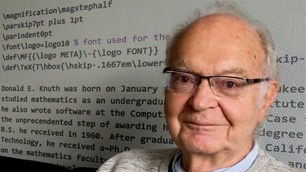

### Formulas

Write this image as an inline formula:

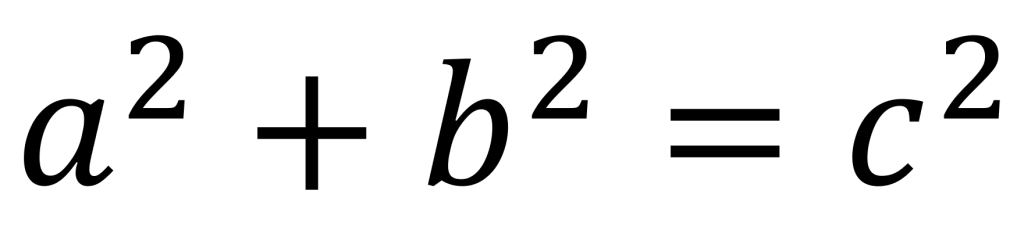

$a^2 + b^2 = c^2$

### Starting a new page

# End of this notebook